# Effects of ocean acidification on Crepidula fornicata larval gene expression

```r
p.val=0.1 # FDR cutoff
conds=rldpvals48[rldpvals48$padj.7548<=p.val & !is.na(rldpvals48$padj.7548) & rldpvals48$padj.7548<=p.val & !is.na(rldpvals48$padj.7548),]
rld_data= conds[,c(1:8)]
head(rld_data)
```

```
##                          pH7.5  pH7.5.1  pH7.5.2  pH7.5.3      pH8
## TRINITY_DN11982_c0_g1 7.773026 7.899919 8.317159 8.347263 9.022186
## TRINITY_DN12470_c0_g1 6.392797 4.773987 4.792494 5.151681 4.114300
## TRINITY_DN13143_c0_g1 4.620563 4.689330 4.219435 4.707218 3.002635
## TRINITY_DN13741_c0_g1 2.735888 2.532134 3.366383 2.841416 6.551154
## TRINITY_DN16871_c0_g1 6.649968 6.125657 6.342807 6.375379 5.558827
## TRINITY_DN16990_c0_g1 2.028398 2.401687 2.677309 2.952674 4.658281
##                          pH8.1    pH8.2    pH8.3
## TRINITY_DN11982_c0_g1 8.817474 8.511402 8.929464
## TRINITY_DN12470_c0_g1 4.254972 4.502302 4.429143
## TRINITY_DN13143_c0_g1 2.977679 4.002862 3.120188
## TRINITY_DN13741_c0_g1 4.968403 6.270672 4.968858
## TRINITY_DN16871_c0_g1 5.431505 5.841383 5.619163
## TRINITY_DN16990_c0_g1 4.646543 4.122390 4.198874
```

```r
nrow(rld_data)
```

```
## [1] 33
```

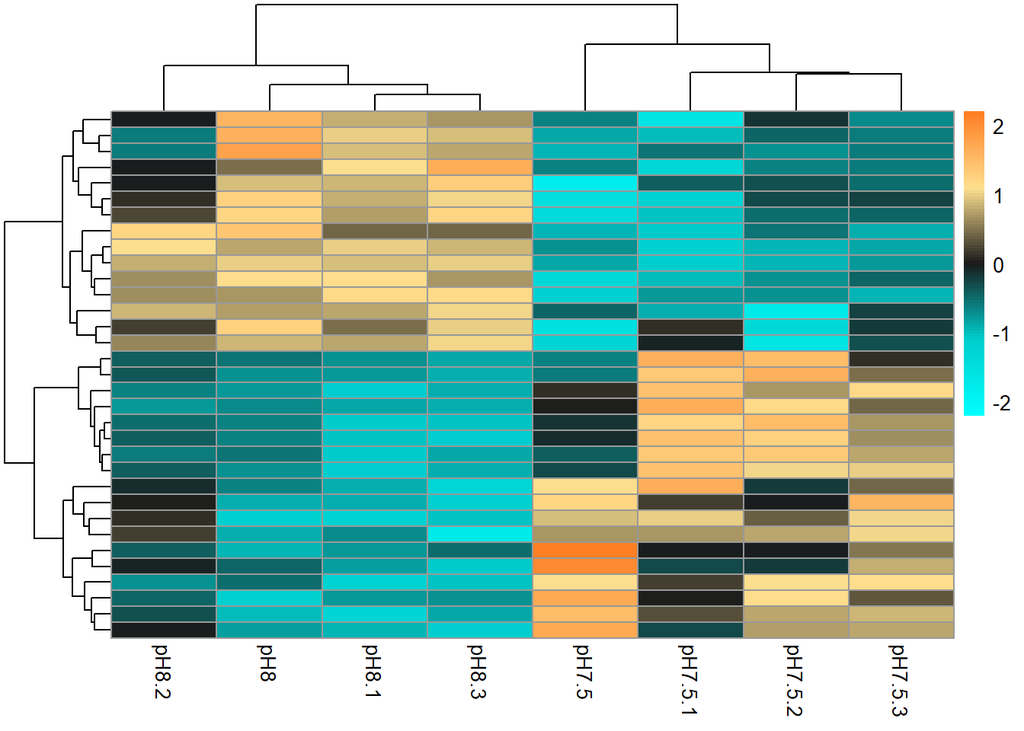

```r
means=apply(rld_data,1,mean) # means of rows
explc=rld_data-means # subtracting them

pheatmap(explc,cluster_cols=T,scale="row",color=col0, show_rownames = F)
```

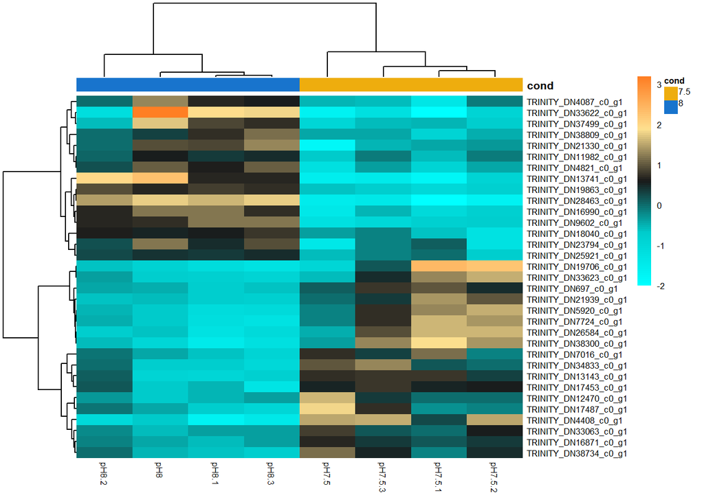

```r
# Make annotation table for pheatmap
ann = data.frame(cond = c('7.5', '7.5', '7.5', '7.5', '8', '8', '8', '8'))
rownames(ann) <- names(explc)

# Set colors
Var1        <- c("darkgoldenrod2", "dodgerblue3")
names(Var1) <- c("7.5", "8")
anno_colors <- list(cond = Var1)

pheatmap(as.matrix(explc),annotation_col=ann,annotation_colors=anno_colors,cex=0.8,color=col0,border_color=NA,clustering_distance_rows="correlation",clustering_distance_cols="correlation", show_rownames=T)
```

```r
head(conds)
```

```
##                          pH7.5  pH7.5.1  pH7.5.2  pH7.5.3      pH8
## TRINITY_DN11982_c0_g1 7.773026 7.899919 8.317159 8.347263 9.022186
## TRINITY_DN12470_c0_g1 6.392797 4.773987 4.792494 5.151681 4.114300
## TRINITY_DN13143_c0_g1 4.620563 4.689330 4.219435 4.707218 3.002635
## TRINITY_DN13741_c0_g1 2.735888 2.532134 3.366383 2.841416 6.551154
## TRINITY_DN16871_c0_g1 6.649968 6.125657 6.342807 6.375379 5.558827
## TRINITY_DN16990_c0_g1 2.028398 2.401687 2.677309 2.952674 4.658281
##                          pH8.1    pH8.2    pH8.3    pval.7548    padj.7548
## TRINITY_DN11982_c0_g1 8.817474 8.511402 8.929464 1.055281e-04 6.574401e-02
## TRINITY_DN12470_c0_g1 4.254972 4.502302 4.429143 2.113890e-04 9.976920e-02
## TRINITY_DN13143_c0_g1 2.977679 4.002862 3.120188 3.212945e-06 3.336108e-03
## TRINITY_DN13741_c0_g1 4.968403 6.270672 4.968858 3.406387e-17 2.652724e-13
## TRINITY_DN16871_c0_g1 5.431505 5.841383 5.619163 1.713593e-04 8.896401e-02
## TRINITY_DN16990_c0_g1 4.646543 4.122390 4.198874 1.955735e-10 6.092114e-07
```

There were no DEGs in common between pH 7.5 samples relative to pH 8.0 samples at hours 4, 10, and 24. There were 33 for hour 48.

Figure 3: Heatmap of top DEGs (FDR-adjusted = 0.1) in common between pH 7.5 samples relative to pH 8.0 samples at hour 48. Columns are indicative of independent libraries and rows represent genes. Colors show fold changes for the genes relative to the mean of the genes. Hierarchical clustering of samples and genes are based on Pearson’s correlation.

Conclusion: We assessed changes in the gene expression of the intertidal snail Crepidula fornicata after exposure to ocean acidification stress for 4, 10, 24, and 48 hours. We found 33 differentially expressed genes (DEGs) between the pH 7.5 and pH 8.0 treatments at hour 48, with 18 genes upregulated and 15 downregulated by the pH 7.5 treatment relative to the control. Only two DEGs were found at hour 4 (1 upregulated, 1 downregulated) and no DEGs were found for hours 10 and 24. Go enrichment analysis identified differential enrichment between hours, with mitochondrial structures and functions, electron transport, and cytoskeleton consistently positively enriched. Ribosomal and nuclear functions, oxidoreductase, and kinases differed in the direction of their enrichment between hours. CCA showed that samples clustered more by hour than by pH treatment, although this relationship was found to not be significant. These analyses suggest that it may take several days for C. fornicata genes to express differentially when exposed to OA stress and that it takes longer than 48 hours to see broad changes in the transcriptome, but that the transcriptome does start to change even within several hours of exposure. Future studies should aim at analyzing gene expression across various other time intervals within different life stages to get a more holistic representation of how an organism is affected by a stressor.